# Anthozoan Coral eDNA Metabarcoding Bioinformatics Analysis

Luke McCartin

2023-10-27

This R markdown file accompanies McCartin et al. 2023 “Nuclear eDNA Metabarcoding Primers for Anthozoan Coral Biodiversity Assessment”. It assumes that you have generated amplicon sequencing data generated on the Illumina MiSeq platform, and that the data are demultiplexed. It is suitable for the analysis of anthozoan coral metabarcoding data generated using the Anth-28S-eDNA or Scler-28S-eDNA primers described in our paper.

The analysis requires a number of commonly used bioinformatic packages that are implemented in either zsh or R code chunks. Please be sure to cite these packages if you plan to use this code for your analyses. These packages are installed in conda environments on my computer (https://conda.io/projects/conda/en/latest/index.html).

cutadapt: Martin, M. (2011). Cutadapt removes adapter sequences from high-throughput sequencing reads. EMBnet.Journal, 17(1), 10–12. https://doi.org/10.14806/ej.17.1.200

DADA2: Callahan, B. J., McMurdie, P. J., Rosen, M. J., Han, A. W., Johnson, A. J. A., and Holmes, S. P. (2016). DADA2: High resolution sample inference from Illumina amplicon data. Nature Methods, 13(7), 581–583. https://doi.org/10.1038/nmeth.3869

BLAST: Altschul, S. F., Gish, W., Miller, W., Myers, E. W., and Lipman, D. J. (1990). Basic local alignment search tool. Journal of Molecular Biology, 215(3), 403–410. https://doi.org/10.1016/s0022-2836(05)80360-2

LULU: Frøslev, T. G., Kjøller, R., Bruun, H. H., Ejrnæs, R., Brunbjerg, A. K., Pietroni, C., and Hansen, A. J. (2017). Algorithm for post-clustering curation of DNA amplicon data yields reliable biodiversity estimates. Nature Communications, 8(1), 1188. https://doi.org/10.1038/s41467-017-01312-x

tidyverse: Wickham, H., Averick, M., Bryan, J., Chang, W., McGowan, L., François, R., Grolemund, G., Hayes, A., Henry, L., Hester, J., Kuhn, M., Pedersen, T., Miller, E., Bache, S., Müller, K., Ooms, J., Robinson, D., Seidel, D., Spinu, V., Takahashi, K., Vaughan, D., Wilke, C., Woo, K., and Yutani, H. (2019). Welcome to the Tidyverse. Journal of Open Source Software, 4(43), 1686. https://doi.org/10.21105/joss.01686

For the sake of this demonstration, I am going to analyze four eDNA metabarcoding libraries generated from samples using the Anth-28S-eDNA primers. For the Scler-28S primers, simply replace the primer sequences at the primer-trimming step and replace the reference database files for taxonomic classification. The following two lines can be used for the Scler-28S primers in place of Lines 59-60.

-a “^AKGGAAACGAATGGRCTMAG;required…CTTGAAACACGGACCAAGGA;optional”  
-A “^TCCTTGGTCCGTGTTTCAAG;required…CTKAGYCCATTCGTTTCCMT;optional”

Make sure that you adjust the parameters of each command depending on the specifics of your dataset. For instance, the parameters of the filterAndTrim function in chunk DADA2 should be adjusted depending on the quality profiles of your dataset and the read length that you’ve used.

1. Trimming primers from the reads using cutadapt (Martin 2011; DOI:10.14806/ej.17.1.200)

Cutadapt is installed in a conda environment on my computer as described in the documentation for the software: https://cutadapt.readthedocs.io/en/v2.0/installation.html.

```bash
conda activate cutadaptenv #activating the cutadapt conda environment

cd ~/Anthozoan_eDNA_metabarcoding_analysis #navigate to your working directory here

mkdir primers-trimmed #making a directory for the files with the primers trimmed

#The following code runs cutadapt in a for loop to trim the primers from the reads using the default parameters.
for sample in *_S*_R1_001.fastq.gz; do
  SAMPLE=$(echo ${sample} | sed "s/_R1_\001\.fastq.gz//")
  cutadapt \
  -a "^CGTGAAACCGYTRRAAGGG;required...CGTCTTGAAACACGGACCAA;optional" \
  -A "^TTGGTCCGTGTTTCAAGACG;required...CCCTTYYARCGGTTTCACG;optional" \
  --action trim --discard-untrimmed \
  --pair-filter=any \
  -o ./primers-trimmed/primers-trimmed-${SAMPLE}_R1_001.fastq.gz -p ./primers-trimmed/primers-trimmed-${SAMPLE}_R2_001.fastq.gz \
  ${SAMPLE}_R1_001.fastq.gz ${SAMPLE}_R2_001.fastq.gz
done

conda deactivate
```

```
## Command line parameters: -a ^CGTGAAACCGYTRRAAGGG;required...CGTCTTGAAACACGGACCAA;optional -A ^TTGGTCCGTGTTTCAAGACG;required...CCCTTYYARCGGTTTCACG;optional --action trim --discard-untrimmed --pair-filter=any -o ./primers-trimmed/primers-trimmed-1368-21-SH18312-meso-octo_S21_L001_R1_001.fastq.gz -p…
## Processing paired-end reads on 1 core ...
## Finished in 1.718 s (45.072 µs/read; 1.33 M reads/minute).
##
## === Summary ===
##
## Total read pairs processed:             38,116
##   Read 1 with adapter:                  34,642 (90.9%)
##   Read 2 with adapter:                  36,488 (95.7%)
##
## == Read fate breakdown ==
## Pairs discarded as untrimmed:            3,696 (9.7%)
## Pairs written (passing filters):        34,420 (90.3%)
##
## Total basepairs processed:    22,945,832 bp
##   Read 1:    11,472,916 bp
##   Read 2:    11,472,916 bp
## Total written (filtered):     19,343,775 bp (84.3%)
##   Read 1:     9,689,656 bp
##   Read 2:     9,654,119 bp
##
## === First read: Adapter 1 ===
##
## Sequence: CGTGAAACCGYTRRAAGGG...CGTCTTGAAACACGGACCAA; Type: linked; Length: 19+20; 5' trimmed: 34642 times; 3' trimmed: 150 times
##
## Minimum overlap: 19+3
## No. of allowed errors: 1
##
## No. of allowed errors:
## 1-9 bp: 0; 10-19 bp: 1; 20 bp: 2
##
## Overview of removed sequences at 5' end
## length   count   expect  max.err error counts
## 18   90  0.0 1   0 90
## 19   34541   0.0 1   33337 1204
## 20   11  0.0 1   0 11
##
##
##
## Overview of removed sequences at 3' end
```

[output cut: 360 more lines]

```
## 4    1   171.1   0   1
## 7    1   2.7 0   1
## 9    2   0.2 0   0 2
## 11   2   0.0 1   0 2
## 28   2   0.0 1   1 1
## 30   1   0.0 1   0 1
## 42   41  0.0 1   25 16
## 43   3   0.0 1   0 3
## 44   2   0.0 1   1 1
## 54   10  0.0 1   7 3
## 55   3   0.0 1   2 1
## 100  5   0.0 1   5
## 138  14  0.0 1   14
## 170  10  0.0 1   10
## 171  1   0.0 1   1
```

2. Quality filtering, denoising, merging and removing chimeric reads using DADA2 (Callahan 2016; https://doi.org/10.1038/nmeth.3869) to generate an amplicon sequence variant (ASV) counts table and .fasta files with denoised ASVs. Much of this code is taken directly from the DADA2 tutorial: https://benjjneb.github.io/dada2/tutorial.html.

```r
library(dada2)
setwd("~/Anthozoan_eDNA_metabarcoding_analysis") #navigate to your working directory here

fnFs <- list.files("./primers-trimmed", pattern="_R1_001.fastq.gz", full.names=TRUE) #listing and define the fastq.gz files with trimmed, forward reads
fnRs <- list.files("./primers-trimmed", pattern="_R2_001.fastq.gz", full.names=TRUE) #listing and define the fastq.gz files with trimmed, reverse reads
head(fnFs)
```

```
## [1] "./primers-trimmed/primers-trimmed-1368-21-SH18312-meso-octo_S21_L001_R1_001.fastq.gz"
## [2] "./primers-trimmed/primers-trimmed-1368-22-SH18313-meso-octo_S22_L001_R1_001.fastq.gz"
## [3] "./primers-trimmed/primers-trimmed-1368-23-SH18314-meso-octo_S23_L001_R1_001.fastq.gz"
## [4] "./primers-trimmed/primers-trimmed-1368-24-SH18315-meso-octo_S24_L001_R1_001.fastq.gz"
```

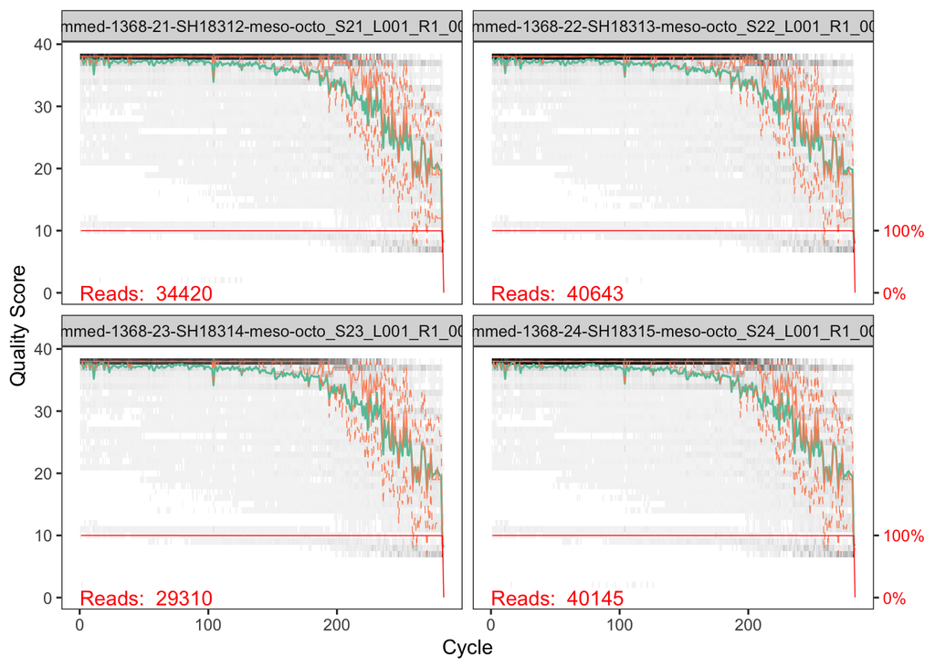

```r
plotQualityProfile(fnFs[c(1:4)]) #plotting quality of forward reads
```

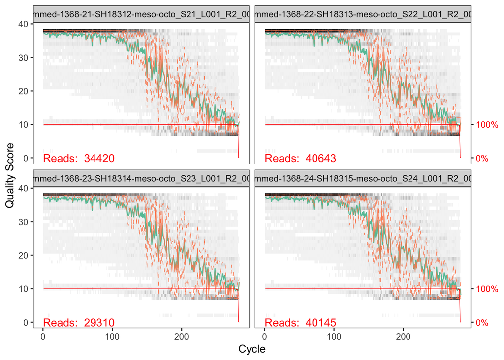

```r
plotQualityProfile(fnRs[c(1:4)]) #plotting quality of reverse reads
```

```r
filtFs <- file.path("filtered", basename(fnFs)) #creating a directory for the filtered forward reads
filtRs <- file.path("filtered", basename(fnRs)) #creating a directory for the filtered reverse reads

out <- filterAndTrim(fnFs, filtFs, fnRs, filtRs, truncLen = c(250, 175), verbose = TRUE) #quality filtering the reads and truncating them to 250 (forward) and 175 (reverse) bp based off of their quality profiles
```

```
## Creating output directory: filtered
```

```
## Read in 34420 paired-sequences, output 34314 (99.7%) filtered paired-sequences.
```

```
## Read in 40643 paired-sequences, output 40595 (99.9%) filtered paired-sequences.
```

```
## Read in 29310 paired-sequences, output 29238 (99.8%) filtered paired-sequences.
```

```
## Read in 40145 paired-sequences, output 40011 (99.7%) filtered paired-sequences.
```

```r
#The following code defines the paths to the filtered files, which is necessary in case some sequence files have no reads that pass the filter (reasonable for negative control samples).
filt_fnFs <- list.files('./filtered', pattern="_R1_001.fastq.gz", full.names=TRUE)
filt_fnRs <- list.files('./filtered', pattern="_R2_001.fastq.gz", full.names=TRUE)
filtFs <- file.path('./filtered', basename(filt_fnFs))
filtRs <- file.path('./filtered', basename(filt_fnRs))

errF <- learnErrors(filtFs, multi=TRUE, verbose = TRUE) #learning the error models for the forward, filtered reads
```

```
## 36039500 total bases in 144158 reads from 4 samples will be used for learning the error rates.
## Initializing error rates to maximum possible estimate.
## selfConsist step 1 ....
##    selfConsist step 2
##    selfConsist step 3
##    selfConsist step 4
##    selfConsist step 5
## Convergence after  5  rounds.
```

```r
errR <- learnErrors(filtRs, multi=TRUE, verbose = TRUE) #learning the error models for the reverse, filtered reads
```

```
## 25227650 total bases in 144158 reads from 4 samples will be used for learning the error rates.
## Initializing error rates to maximum possible estimate.
## selfConsist step 1 ....
##    selfConsist step 2
##    selfConsist step 3
##    selfConsist step 4
##    selfConsist step 5
## Convergence after  5  rounds.
```

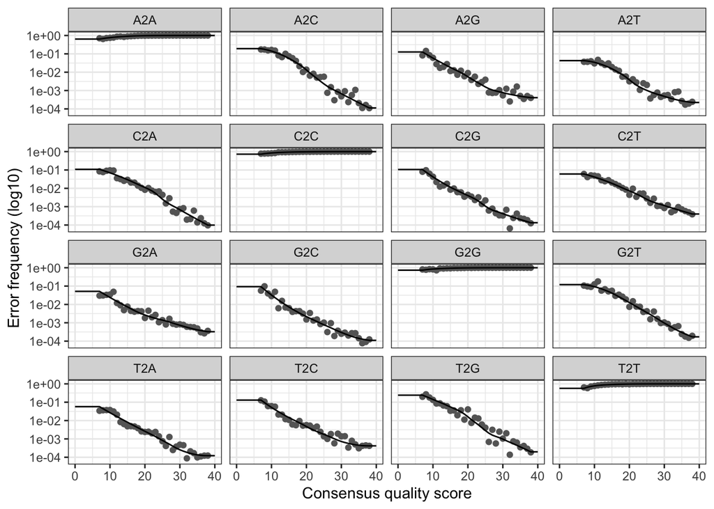

```r
plotErrors(errF) #plotting the fit of the forward error model
```

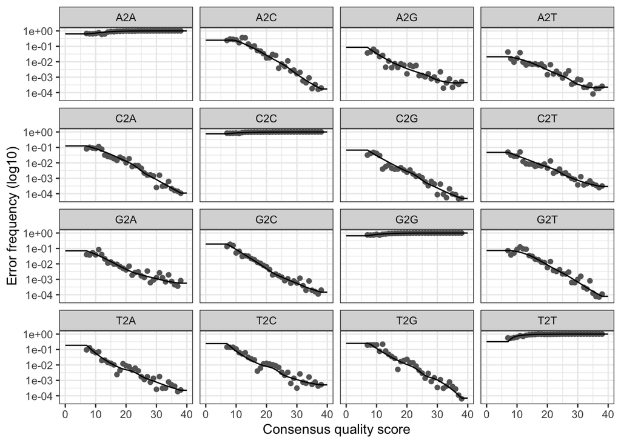

```r
plotErrors(errR) #plotting the fit of the reverse error model
```

```r
ddF <- dada(filtFs, errF, pool="pseudo", multi=TRUE) #denoising the forward reads
```

```
## Sample 1 - 34314 reads in 7989 unique sequences.
## Sample 2 - 40595 reads in 9468 unique sequences.
## Sample 3 - 29238 reads in 6957 unique sequences.
## Sample 4 - 40011 reads in 9378 unique sequences.
##
##    selfConsist step 2
```

```r
ddR <- dada(filtRs, errR, pool="pseudo", multi=TRUE) #denoising the reverse reads
```

```
## Sample 1 - 34314 reads in 8716 unique sequences.
## Sample 2 - 40595 reads in 10665 unique sequences.
## Sample 3 - 29238 reads in 7509 unique sequences.
## Sample 4 - 40011 reads in 9480 unique sequences.
##
##    selfConsist step 2
```

```r
merged <- mergePairs(ddF, filtFs, ddR, filtRs, verbose=TRUE) #merging the read pairs
```

```
## 33760 paired-reads (in 45 unique pairings) successfully merged out of 33850 (in 57 pairings) input.
```

```
## 39801 paired-reads (in 134 unique pairings) successfully merged out of 40066 (in 194 pairings) input.
```

```
## 28835 paired-reads (in 42 unique pairings) successfully merged out of 28873 (in 51 pairings) input.
```

```
## 39401 paired-reads (in 63 unique pairings) successfully merged out of 39501 (in 83 pairings) input.
```

```r
table.chimeras <- makeSequenceTable(merged) #constructing the ASV counts table

table.no.chimeras <- removeBimeraDenovo(table.chimeras, multi=TRUE, verbose=TRUE) #removing chimeric ASVs
```

```
## Identified 135 bimeras out of 184 input sequences.
```

```r
#The following code
getN <- function(x) sum(getUniques(x))
track <- cbind(out, sapply(ddF, getN), sapply(ddR, getN), sapply(merged, getN), rowSums(table.no.chimeras))
colnames(track) <- c("input", "filtered", "denoisedF", "denoisedR", "merged", "nonchim")
rownames(track) <- basename(fnFs)
head(track)
```

```
##                                                                    input
## primers-trimmed-1368-21-SH18312-meso-octo_S21_L001_R1_001.fastq.gz 34420
## primers-trimmed-1368-22-SH18313-meso-octo_S22_L001_R1_001.fastq.gz 40643
## primers-trimmed-1368-23-SH18314-meso-octo_S23_L001_R1_001.fastq.gz 29310
## primers-trimmed-1368-24-SH18315-meso-octo_S24_L001_R1_001.fastq.gz 40145
##                                                                    filtered
## primers-trimmed-1368-21-SH18312-meso-octo_S21_L001_R1_001.fastq.gz    34314
## primers-trimmed-1368-22-SH18313-meso-octo_S22_L001_R1_001.fastq.gz    40595
## primers-trimmed-1368-23-SH18314-meso-octo_S23_L001_R1_001.fastq.gz    29238
## primers-trimmed-1368-24-SH18315-meso-octo_S24_L001_R1_001.fastq.gz    40011
##                                                                    denoisedF
## primers-trimmed-1368-21-SH18312-meso-octo_S21_L001_R1_001.fastq.gz     34012
## primers-trimmed-1368-22-SH18313-meso-octo_S22_L001_R1_001.fastq.gz     40301
## primers-trimmed-1368-23-SH18314-meso-octo_S23_L001_R1_001.fastq.gz     29009
## primers-trimmed-1368-24-SH18315-meso-octo_S24_L001_R1_001.fastq.gz     39683
##                                                                    denoisedR
## primers-trimmed-1368-21-SH18312-meso-octo_S21_L001_R1_001.fastq.gz     34041
## primers-trimmed-1368-22-SH18313-meso-octo_S22_L001_R1_001.fastq.gz     40215
## primers-trimmed-1368-23-SH18314-meso-octo_S23_L001_R1_001.fastq.gz     28995
## primers-trimmed-1368-24-SH18315-meso-octo_S24_L001_R1_001.fastq.gz     39696
##                                                                    merged
## primers-trimmed-1368-21-SH18312-meso-octo_S21_L001_R1_001.fastq.gz  33760
## primers-trimmed-1368-22-SH18313-meso-octo_S22_L001_R1_001.fastq.gz  39801
## primers-trimmed-1368-23-SH18314-meso-octo_S23_L001_R1_001.fastq.gz  28835
## primers-trimmed-1368-24-SH18315-meso-octo_S24_L001_R1_001.fastq.gz  39401
##                                                                    nonchim
## primers-trimmed-1368-21-SH18312-meso-octo_S21_L001_R1_001.fastq.gz   32913
## primers-trimmed-1368-22-SH18313-meso-octo_S22_L001_R1_001.fastq.gz   37676
## primers-trimmed-1368-23-SH18314-meso-octo_S23_L001_R1_001.fastq.gz   28119
## primers-trimmed-1368-24-SH18315-meso-octo_S24_L001_R1_001.fastq.gz   38452
```

```r
write.csv(track, "pipeline_stats.csv") #writing this to a file

write.table(t(table.no.chimeras), file = 'table.tsv', sep = "\t", row.names = TRUE, col.names=NA, quote=FALSE) #writing the ASV counts table to a file

uniquesToFasta(table.no.chimeras, fout='rep-seqs.fasta', ids = paste("ASV",1:ncol(table.no.chimeras),sep="_")) #writing the ASVS to a .fasta file as well
```

3. Conducting a BLAST search of the ASVs by querying them against GenBank.

BLAST and entrez-direct are installed in a conda environment separate from cutadapt on my computer. The environment is named “blast”. Both can be installed by navigating to their pages on https://anaconda.org/.

```bash
cd ~/Anthozoan_eDNA_metabarcoding_analysis

conda activate blast

blastn -db nt -remote -query rep-seqs.fasta -out BLAST_results.tsv -max_target_seqs 10 -outfmt "6 qseqid qlen sseqid staxids slen sstart send length pident evalue"

awk '{print $4}' BLAST_results.tsv > taxid.txt #extracting the fourth column, which contains the subject taxonomy ids of each subject sequence
efetch -input "taxid.txt" -db "Taxonomy" -format docsum | xtract -pattern DocumentSummary -element Id Division Genus Species > taxonomy.txt #returning the taxonomic identifications of for each taxonomy id #

awk 'BEGIN{RS=">";OFS="\t"}NR>1{print $1,$2}' rep-seqs.fasta > rep-seqs.tsv

conda deactivate
```

4. Filtering the sequences to corals based off of their top BLAST hits. This chunk of code relies on the ‘tidyverse’ packages (Wickham et al. 2019; doi:10.21105/joss.01686)

```r
setwd("~/Anthozoan_eDNA_metabarcoding_analysis")

library(tidyverse)
blast <- read.delim("BLAST_results.tsv", header = FALSE) #reading in the blast results

blast.taxonomy <- read.delim("taxonomy.txt", header = FALSE)
blast.taxonomy$V1 <- as.character(blast.taxonomy$V1)
blast.taxonomy.distinct <- distinct(blast.taxonomy)
blast.hits.taxonomy <- left_join(blast, blast.taxonomy, by = c("V4" = "V1")) #merging the blast hits with their taxonomic identities
#The following code filters the data anthozoan ASVs reads based on their top BLAST hit (smallest e-value), a percent identity of 90% to a coral and a coverage across the queried sequence of 90%.
blast.top.anth <- blast.hits.taxonomy %>%
  group_by(V1) %>%
  filter(V10 == min(V10)) %>%
  filter(V2.y %in% c('stony corals', 'black corals', 'blue corals', 'soft corals')) %>%
  filter(V8/V2.x >= .90) %>%
  filter(V9 >= 90)

anth.ids <- unique(blast.top.anth$V1) #defining the ASVs that are anthozoan corals

seqs <- read.delim("rep-seqs.tsv", header = FALSE) #reading in the file with the ASV sequences
anth.seqs <- filter(seqs, V1 %in% anth.ids)

write.table(anth.seqs, file = 'coral-rep-seqs.tsv', sep = "\t", row.names = FALSE, col.names = FALSE, quote = FALSE) #writing the sequences that are coral and their names for creating a BLAST database to be used with LULU

table = read.delim("table.tsv", row.names = 1, sep = '\t') #reading in the ASV counts table
table$seq <- row.names(table)
table.anth <- left_join(anth.seqs, table, by = c('V2'='seq')) #defining the table with only Anthozoan coral ASVs

write.table(table.anth, file = 'coral_table.tsv', sep = "\t", row.names = FALSE, col.names=TRUE, quote=FALSE) #write this coral table to file
```

5. Generating a match list of the coral ASVs for curation with LULU (Frøslev et al. 2017; https://doi.org/10.1038/s41467-017-01312-x)

```bash
cd ~/Anthozoan_eDNA_metabarcoding_analysis

conda activate blast

awk -F '\t' '{printf ">%s\n%s\n",$1,$2}' coral-rep-seqs.tsv > coral-rep-seqs.fasta #converting the coral seqs in a .tsv format to a .fasta file

makeblastdb -in coral-rep-seqs.fasta -parse_seqids -dbtype nucl #creating a matchlist by first creating a BLAST database...
blastn -db coral-rep-seqs.fasta -outfmt '6 qseqid sseqid pident' -out match_list.txt -qcov_hsp_perc 80 -query coral-rep-seqs.fasta #...and then conducting a BLAST search on the sequences against one another

conda deactivate
```

```
##
##
## Building a new DB, current time: 10/29/2023 18:58:53
## New DB name:   /Users/paragorgia/Anthozoan_eDNA_metabarcoding_analysis/coral-rep-seqs.fasta
## New DB title:  coral-rep-seqs.fasta
## Sequence type: Nucleotide
## Deleted existing Nucleotide BLAST database named /Users/paragorgia/Anthozoan_eDNA_metabarcoding_analysis/coral-rep-seqs.fasta
## Keep MBits: T
## Maximum file size: 3000000000B
## Adding sequences from FASTA; added 34 sequences in 0.177164 seconds.
```

6. Curating the ASVs with LULU and using the assignTaxonomy and assignSpecies functions implemented in DADA2 to classify their taxonomy. The code to run LULU is taken from the LULU tutorial (https://github.com/tobiasgf/lulu), and the code to classify the taxonomy of the ASVs is taken from the Taxonomic Assignment page on the DADA2 website (https://benjjneb.github.io/dada2/assign.html).

For this example, I am going to use the taxonomic classifier file for anthozoan sequences amplified using the Anth-28S-eDNA primers.

```r
library(tidyverse)
library(dada2)
library(lulu)

setwd('/Users/paragorgia/Anthozoan_eDNA_metabarcoding_analysis')

anth.table <- read.delim('coral_table.tsv')
seq.ids <- read.delim('coral-rep-seqs.tsv', header = FALSE)

row.names(anth.table) <- anth.table$V1
anth.table <- subset(anth.table, select = -c(V1, V2))

match.list <- read.delim('match_list.txt', header = FALSE)

curated.table <- lulu(anth.table, match.list, minimum_match = 95)
```

```
## [1] "progress: 3%"
## [1] "progress: 6%"
## [1] "progress: 9%"
## [1] "progress: 12%"
## [1] "progress: 15%"
## [1] "progress: 18%"
## [1] "progress: 21%"
## [1] "progress: 24%"
## [1] "progress: 26%"
## [1] "progress: 29%"
## [1] "progress: 32%"
## [1] "progress: 35%"
## [1] "progress: 38%"
## [1] "progress: 41%"
## [1] "progress: 44%"
```

[output cut: 19 more lines]

```r
curated.table.df <- curated.table$curated_table
curated.table.df$seq.id <- row.names(curated.table.df)

curated.table.df <- left_join(curated.table.df, seq.ids, by = c("seq.id" = "V1"))
row.names(curated.table.df) <- curated.table.df$seq.id

seqs <- curated.table.df$V2
system.time(tax <- assignTaxonomy(seqs, "Anth_28S_assignTaxonomy_global_20231024.fasta", multi=TRUE, minBoot = 80,
                                  taxLevels = c("Kingdom", "Phylum", "Class", "Order", "Family", "Genus"))) #classifying to the genus level with assignTaxonomy
```

```
##    user  system elapsed
##   0.302   0.058   0.373
```

```r
unname(head(tax))
```

```
##      [,1]       [,2]       [,3]       [,4]
## [1,] "Animalia" "Cnidaria" "Anthozoa" "Malacalcyonacea"
## [2,] "Animalia" "Cnidaria" "Anthozoa" "Malacalcyonacea"
## [3,] "Animalia" "Cnidaria" "Anthozoa" "Malacalcyonacea"
## [4,] "Animalia" "Cnidaria" "Anthozoa" "Antipatharia"
## [5,] "Animalia" "Cnidaria" "Anthozoa" "Malacalcyonacea"
## [6,] "Animalia" "Cnidaria" "Anthozoa" "Antipatharia"
##      [,5]                             [,6]
## [1,] "Malacalcyonacea_incertae_sedis" "Thesea"
## [2,] NA                               NA
## [3,] "Plexauridae"                    "Muricea"
## [4,] "Antipathidae"                   "Stichopathes"
## [5,] NA                               NA
## [6,] "Antipathidae"                   "Antipathes"
```

```r
system.time(species <- addSpecies(tax, "Anth_28S_assignSpecies_watlantic_20230912.fasta", allowMultiple=TRUE)) #finding 100% matches to our reference database of Gulf of Mexico corals with assignSpecies
```

```
##    user  system elapsed
##   3.041   0.032   3.084
```

```r
unname(head(species))
```

```
##      [,1]       [,2]       [,3]       [,4]
## [1,] "Animalia" "Cnidaria" "Anthozoa" "Malacalcyonacea"
## [2,] "Animalia" "Cnidaria" "Anthozoa" "Malacalcyonacea"
## [3,] "Animalia" "Cnidaria" "Anthozoa" "Malacalcyonacea"
## [4,] "Animalia" "Cnidaria" "Anthozoa" "Antipatharia"
## [5,] "Animalia" "Cnidaria" "Anthozoa" "Malacalcyonacea"
## [6,] "Animalia" "Cnidaria" "Anthozoa" "Antipatharia"
##      [,5]                             [,6]
## [1,] "Malacalcyonacea_incertae_sedis" "Thesea"
## [2,] NA                               NA
## [3,] "Plexauridae"                    "Muricea"
## [4,] "Antipathidae"                   "Stichopathes"
## [5,] NA                               NA
## [6,] "Antipathidae"                   "Antipathes"
##      [,7]
## [1,] "Thesea_nivea_SH12099_Sanger/Thesea_nivea_SH12099_Skim"
## [2,] NA
## [3,] NA
## [4,] "Stichopathes_sp._SH10725_Sanger/Stichopathes_sp._SH10725_Skim/Stichopathes_sp._SH12098_Skim"
## [5,] NA
## [6,] "Antipathes_atlantica_ANT223/Antipathes_atlantica_FJ626239.1/Antipathes_atlantica_SH11805_Sanger/Antipathes_atlantica_SH11805_Skim/Antipathes_atlantica_SH12117_Sanger"
```

```r
species.df <- as.data.frame(species)
species.df$seq <- row.names(species.df)
species.df.export <- left_join(species.df, curated.table.df, by = c('seq' = 'V2'))

write.table(species.df.export, file = 'Anth_classifier_results.tsv', sep = "\t", row.names = FALSE, quote=FALSE) #writing the ASV counts table with the taxonomic classifications of each coral ASV
```